# Risk Factor Analysis

## Outcome Variable

**Outcome Variable:** y_rate_len

## Predictor Variables

**Intervention Variable:** hdlvry

**Adjustment Set:**

- arm
- sex
- W_mage
- meducyrs
- feducyrs
- hhwealth_quart
- single
- W_nrooms
- brthmon
- W_parity
- impsan
- delta_W_mage
- delta_meducyrs
- delta_feducyrs
- delta_hhwealth_quart
- delta_single
- delta_W_nrooms
- delta_brthmon
- delta_W_parity
- delta_impsan

## Stratifying Variables

The analysis was stratified on these variable(s):

- agecat
- studyid
- country

## Data Summary

| agecat | studyid | country | hdlvry | n_cell | n |
| --- | --- | --- | --- | --- | --- |
| 0-3 months | CMC-V-BCS-2002 | INDIA | 0 | 88 | 88 |
| 0-3 months | CMC-V-BCS-2002 | INDIA | 1 | 0 | 88 |
| 0-3 months | COHORTS | INDIA | 0 | 2863 | 4580 |
| 0-3 months | COHORTS | INDIA | 1 | 1717 | 4580 |
| 0-3 months | EE | PAKISTAN | 0 | 198 | 301 |
| 0-3 months | EE | PAKISTAN | 1 | 103 | 301 |
| 0-3 months | GMS-Nepal | NEPAL | 0 | 113 | 473 |
| 0-3 months | GMS-Nepal | NEPAL | 1 | 360 | 473 |
| 0-3 months | IRC | INDIA | 0 | 370 | 377 |
| 0-3 months | IRC | INDIA | 1 | 7 | 377 |
| 0-3 months | JiVitA-3 | BANGLADESH | 0 | 33 | 313 |
| 0-3 months | JiVitA-3 | BANGLADESH | 1 | 280 | 313 |
| 0-3 months | JiVitA-4 | BANGLADESH | 0 | 369 | 1796 |
| 0-3 months | JiVitA-4 | BANGLADESH | 1 | 1427 | 1796 |
| 0-3 months | NIH-Crypto | BANGLADESH | 0 | 558 | 721 |
| 0-3 months | NIH-Crypto | BANGLADESH | 1 | 163 | 721 |
| 0-3 months | PROVIDE | BANGLADESH | 0 | 478 | 640 |
| 0-3 months | PROVIDE | BANGLADESH | 1 | 162 | 640 |
| 0-3 months | SAS-CompFeed | INDIA | 0 | 140 | 1025 |
| 0-3 months | SAS-CompFeed | INDIA | 1 | 885 | 1025 |
| 3-6 months | CMC-V-BCS-2002 | INDIA | 0 | 298 | 305 |
| 3-6 months | CMC-V-BCS-2002 | INDIA | 1 | 7 | 305 |
| 3-6 months | COHORTS | INDIA | 0 | 2754 | 4481 |
| 3-6 months | COHORTS | INDIA | 1 | 1727 | 4481 |
| 3-6 months | EE | PAKISTAN | 0 | 186 | 278 |
| 3-6 months | EE | PAKISTAN | 1 | 92 | 278 |
| 3-6 months | GMS-Nepal | NEPAL | 0 | 101 | 437 |
| 3-6 months | GMS-Nepal | NEPAL | 1 | 336 | 437 |
| 3-6 months | IRC | INDIA | 0 | 389 | 397 |
| 3-6 months | IRC | INDIA | 1 | 8 | 397 |

[output cut: 122 more lines]

The following strata were considered:

- agecat: 0-3 months, studyid: CMC-V-BCS-2002, country: INDIA
- agecat: 0-3 months, studyid: COHORTS, country: INDIA
- agecat: 0-3 months, studyid: EE, country: PAKISTAN
- agecat: 0-3 months, studyid: GMS-Nepal, country: NEPAL
- agecat: 0-3 months, studyid: IRC, country: INDIA
- agecat: 0-3 months, studyid: JiVitA-3, country: BANGLADESH
- agecat: 0-3 months, studyid: JiVitA-4, country: BANGLADESH
- agecat: 0-3 months, studyid: NIH-Crypto, country: BANGLADESH
- agecat: 0-3 months, studyid: PROVIDE, country: BANGLADESH
- agecat: 0-3 months, studyid: SAS-CompFeed, country: INDIA
- agecat: 12-15 months, studyid: CMC-V-BCS-2002, country: INDIA
- agecat: 12-15 months, studyid: EE, country: PAKISTAN
- agecat: 12-15 months, studyid: GMS-Nepal, country: NEPAL
- agecat: 12-15 months, studyid: IRC, country: INDIA
- agecat: 12-15 months, studyid: JiVitA-4, country: BANGLADESH
- agecat: 12-15 months, studyid: NIH-Crypto, country: BANGLADESH
- agecat: 12-15 months, studyid: PROVIDE, country: BANGLADESH
- agecat: 12-15 months, studyid: SAS-CompFeed, country: INDIA
- agecat: 12-15 months, studyid: SAS-FoodSuppl, country: INDIA
- agecat: 12-15 months, studyid: TanzaniaChild2, country: TANZANIA, UNITED REPUBLIC OF
- agecat: 15-18 months, studyid: CMC-V-BCS-2002, country: INDIA
- agecat: 15-18 months, studyid: EE, country: PAKISTAN
- agecat: 15-18 months, studyid: GMS-Nepal, country: NEPAL
- agecat: 15-18 months, studyid: IRC, country: INDIA
- agecat: 15-18 months, studyid: JiVitA-4, country: BANGLADESH
- agecat: 15-18 months, studyid: NIH-Crypto, country: BANGLADESH
- agecat: 15-18 months, studyid: PROVIDE, country: BANGLADESH
- agecat: 15-18 months, studyid: SAS-CompFeed, country: INDIA
- agecat: 15-18 months, studyid: SAS-FoodSuppl, country: INDIA
- agecat: 15-18 months, studyid: TanzaniaChild2, country: TANZANIA, UNITED REPUBLIC OF
- agecat: 18-21 months, studyid: CMC-V-BCS-2002, country: INDIA
- agecat: 18-21 months, studyid: EE, country: PAKISTAN
- agecat: 18-21 months, studyid: GMS-Nepal, country: NEPAL
- agecat: 18-21 months, studyid: IRC, country: INDIA
- agecat: 18-21 months, studyid: NIH-Crypto, country: BANGLADESH
- agecat: 18-21 months, studyid: PROVIDE, country: BANGLADESH
- agecat: 18-21 months, studyid: TanzaniaChild2, country: TANZANIA, UNITED REPUBLIC OF
- agecat: 21-24 months, studyid: CMC-V-BCS-2002, country: INDIA
- agecat: 21-24 months, studyid: EE, country: PAKISTAN
- agecat: 21-24 months, studyid: GMS-Nepal, country: NEPAL
- agecat: 21-24 months, studyid: IRC, country: INDIA
- agecat: 21-24 months, studyid: NIH-Crypto, country: BANGLADESH
- agecat: 21-24 months, studyid: PROVIDE, country: BANGLADESH
- agecat: 3-6 months, studyid: CMC-V-BCS-2002, country: INDIA
- agecat: 3-6 months, studyid: COHORTS, country: INDIA
- agecat: 3-6 months, studyid: EE, country: PAKISTAN
- agecat: 3-6 months, studyid: GMS-Nepal, country: NEPAL
- agecat: 3-6 months, studyid: IRC, country: INDIA
- agecat: 3-6 months, studyid: JiVitA-3, country: BANGLADESH
- agecat: 3-6 months, studyid: JiVitA-4, country: BANGLADESH
- agecat: 3-6 months, studyid: NIH-Crypto, country: BANGLADESH
- agecat: 3-6 months, studyid: PROVIDE, country: BANGLADESH
- agecat: 3-6 months, studyid: SAS-CompFeed, country: INDIA
- agecat: 3-6 months, studyid: TanzaniaChild2, country: TANZANIA, UNITED REPUBLIC OF
- agecat: 6-9 months, studyid: CMC-V-BCS-2002, country: INDIA
- agecat: 6-9 months, studyid: COHORTS, country: INDIA
- agecat: 6-9 months, studyid: EE, country: PAKISTAN
- agecat: 6-9 months, studyid: GMS-Nepal, country: NEPAL
- agecat: 6-9 months, studyid: IRC, country: INDIA
- agecat: 6-9 months, studyid: JiVitA-4, country: BANGLADESH
- agecat: 6-9 months, studyid: NIH-Crypto, country: BANGLADESH
- agecat: 6-9 months, studyid: PROVIDE, country: BANGLADESH
- agecat: 6-9 months, studyid: SAS-CompFeed, country: INDIA
- agecat: 6-9 months, studyid: SAS-FoodSuppl, country: INDIA
- agecat: 6-9 months, studyid: TanzaniaChild2, country: TANZANIA, UNITED REPUBLIC OF
- agecat: 9-12 months, studyid: CMC-V-BCS-2002, country: INDIA
- agecat: 9-12 months, studyid: COHORTS, country: INDIA
- agecat: 9-12 months, studyid: EE, country: PAKISTAN
- agecat: 9-12 months, studyid: GMS-Nepal, country: NEPAL
- agecat: 9-12 months, studyid: IRC, country: INDIA
- agecat: 9-12 months, studyid: JiVitA-4, country: BANGLADESH
- agecat: 9-12 months, studyid: NIH-Crypto, country: BANGLADESH
- agecat: 9-12 months, studyid: PROVIDE, country: BANGLADESH
- agecat: 9-12 months, studyid: SAS-CompFeed, country: INDIA
- agecat: 9-12 months, studyid: SAS-FoodSuppl, country: INDIA
- agecat: 9-12 months, studyid: TanzaniaChild2, country: TANZANIA, UNITED REPUBLIC OF

### Dropped Strata

Some strata were dropped due to rare outcomes:

- agecat: 0-3 months, studyid: CMC-V-BCS-2002, country: INDIA
- agecat: 18-21 months, studyid: TanzaniaChild2, country: TANZANIA, UNITED REPUBLIC OF

## Methods Detail

We’re interested in the causal parameters $E[Y_a]$ for all values of $a \in \mathcal{A}$. These parameters represent the mean outcome if, possibly contrary to fact, we intervened to set all units to have $A=a$. Under the randomization and positivity assumptions, these are identified by the statistical parameters $\psi_a=E_W[E_{Y|A,W}(Y|A=a,W)]$. In addition, we’re interested in the mean of $Y$, $E[Y]$ under no intervention (the observed mean). We will estimate these parameters by using SuperLearner to fit the relevant likelihood factors – $E_{Y|A,W}(Y|A=a,W)$ and $p(A=a|W)$, and then updating our likelihood fit using a joint TMLE.

For unadjusted analyses ($W=\{\}$), initial likelihoods were estimated using Lrnr_glm to estimate the simple $E(Y|A)$ and Lrnr_mean to estimate $p(A)$. For adjusted analyses, a small library containing Lrnr_glmnet, Lrnr_xgboost, and Lrnr_mean was used.

Having estimated these parameters, we will then use the delta method to estimate relative risks and attributable risks relative to a prespecified baseline level of $A$.

# Results Detail

## Results Plots

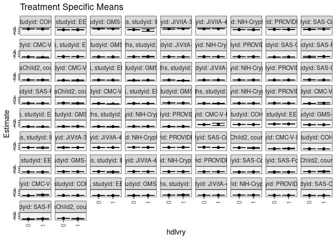

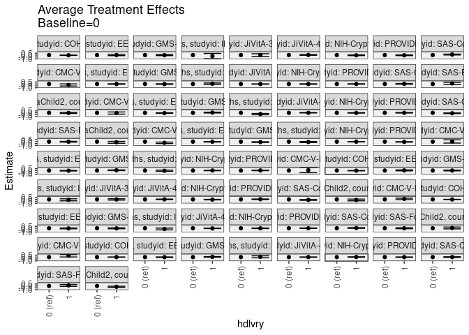

[figure not shown]

## Results Table

### Parameter: TSM

| agecat | studyid | country | intervention_level | baseline_level | estimate | ci_lower | ci_upper |
| --- | --- | --- | --- | --- | --- | --- | --- |
| 0-3 months | COHORTS | INDIA | 0 | NA | 3.5053340 | 3.4816190 | 3.5290489 |
| 0-3 months | COHORTS | INDIA | 1 | NA | 3.4584348 | 3.4248938 | 3.4919758 |
| 0-3 months | EE | PAKISTAN | 0 | NA | 3.0683917 | 2.9583552 | 3.1784283 |
| 0-3 months | EE | PAKISTAN | 1 | NA | 3.0864117 | 2.9637709 | 3.2090524 |
| 0-3 months | GMS-Nepal | NEPAL | 0 | NA | 3.6266405 | 3.5220777 | 3.7312033 |
| 0-3 months | GMS-Nepal | NEPAL | 1 | NA | 3.6127595 | 3.5508392 | 3.6746797 |
| 0-3 months | IRC | INDIA | 0 | NA | 3.1431413 | 3.0310208 | 3.2552617 |
| 0-3 months | IRC | INDIA | 1 | NA | 2.8796715 | 2.1905479 | 3.5687951 |
| 0-3 months | JiVitA-3 | BANGLADESH | 0 | NA | 3.6798462 | 3.3189432 | 4.0407492 |
| 0-3 months | JiVitA-3 | BANGLADESH | 1 | NA | 3.6788095 | 3.6160032 | 3.7416159 |
| 0-3 months | JiVitA-4 | BANGLADESH | 0 | NA | 3.6054966 | 3.5157034 | 3.6952897 |
| 0-3 months | JiVitA-4 | BANGLADESH | 1 | NA | 3.6455409 | 3.6122346 | 3.6788471 |
| 0-3 months | NIH-Crypto | BANGLADESH | 0 | NA | 3.1447518 | 3.1033418 | 3.1861617 |
| 0-3 months | NIH-Crypto | BANGLADESH | 1 | NA | 3.0904320 | 3.0115469 | 3.1693170 |
| 0-3 months | PROVIDE | BANGLADESH | 0 | NA | 3.2703556 | 3.2271864 | 3.3135248 |
| 0-3 months | PROVIDE | BANGLADESH | 1 | NA | 3.2194920 | 3.1462621 | 3.2927218 |
| 0-3 months | SAS-CompFeed | INDIA | 0 | NA | 3.2673204 | 3.1473009 | 3.3873399 |
| 0-3 months | SAS-CompFeed | INDIA | 1 | NA | 3.4057043 | 3.3708127 | 3.4405958 |
| 3-6 months | CMC-V-BCS-2002 | INDIA | 0 | NA | 1.8068881 | 1.7044670 | 1.9093092 |
| 3-6 months | CMC-V-BCS-2002 | INDIA | 1 | NA | 1.9008428 | 1.2479048 | 2.5537808 |
| 3-6 months | COHORTS | INDIA | 0 | NA | 1.8637782 | 1.8430885 | 1.8844678 |
| 3-6 months | COHORTS | INDIA | 1 | NA | 1.8259798 | 1.7959954 | 1.8559642 |
| 3-6 months | EE | PAKISTAN | 0 | NA | 2.0849026 | 2.0112762 | 2.1585291 |
| 3-6 months | EE | PAKISTAN | 1 | NA | 2.1199809 | 2.0207400 | 2.2192218 |
| 3-6 months | GMS-Nepal | NEPAL | 0 | NA | 1.7098566 | 1.6223664 | 1.7973468 |
| 3-6 months | GMS-Nepal | NEPAL | 1 | NA | 1.7195441 | 1.6715928 | 1.7674954 |
| 3-6 months | IRC | INDIA | 0 | NA | 1.8829475 | 1.8178679 | 1.9480270 |
| 3-6 months | IRC | INDIA | 1 | NA | 1.7701196 | 1.5123539 | 2.0278853 |
| 3-6 months | JiVitA-3 | BANGLADESH | 0 | NA | 1.8940746 | 1.7301104 | 2.0580389 |
| 3-6 months | JiVitA-3 | BANGLADESH | 1 | NA | 1.8746124 | 1.8127362 | 1.9364885 |

[output cut: 118 more lines]

### Parameter: E(Y)

| agecat | studyid | country | intervention_level | baseline_level | estimate | ci_lower | ci_upper |
| --- | --- | --- | --- | --- | --- | --- | --- |
| 0-3 months | COHORTS | INDIA | NA | NA | 3.4928630 | 3.4759520 | 3.5097739 |
| 0-3 months | EE | PAKISTAN | NA | NA | 3.0782627 | 2.9950537 | 3.1614717 |
| 0-3 months | GMS-Nepal | NEPAL | NA | NA | 3.6065886 | 3.5542997 | 3.6588775 |
| 0-3 months | IRC | INDIA | NA | NA | 3.1382493 | 3.0275242 | 3.2489743 |
| 0-3 months | JiVitA-3 | BANGLADESH | NA | NA | 3.6741702 | 3.6068245 | 3.7415159 |
| 0-3 months | JiVitA-4 | BANGLADESH | NA | NA | 3.6373098 | 3.6059106 | 3.6687089 |
| 0-3 months | NIH-Crypto | BANGLADESH | NA | NA | 3.1292449 | 3.0928504 | 3.1656393 |
| 0-3 months | PROVIDE | BANGLADESH | NA | NA | 3.2576810 | 3.2206777 | 3.2946843 |
| 0-3 months | SAS-CompFeed | INDIA | NA | NA | 3.4022425 | 3.3615716 | 3.4429134 |
| 3-6 months | CMC-V-BCS-2002 | INDIA | NA | NA | 1.8090444 | 1.7078462 | 1.9102427 |
| 3-6 months | COHORTS | INDIA | NA | NA | 1.8571473 | 1.8427398 | 1.8715548 |
| 3-6 months | EE | PAKISTAN | NA | NA | 2.0964778 | 2.0380696 | 2.1548860 |
| 3-6 months | GMS-Nepal | NEPAL | NA | NA | 1.7165753 | 1.6754325 | 1.7577181 |
| 3-6 months | IRC | INDIA | NA | NA | 1.8806738 | 1.8168757 | 1.9444719 |
| 3-6 months | JiVitA-3 | BANGLADESH | NA | NA | 1.8747997 | 1.8153916 | 1.9342078 |
| 3-6 months | JiVitA-4 | BANGLADESH | NA | NA | 1.8985588 | 1.8677350 | 1.9293826 |
| 3-6 months | NIH-Crypto | BANGLADESH | NA | NA | 2.0057973 | 1.9693775 | 2.0422170 |
| 3-6 months | PROVIDE | BANGLADESH | NA | NA | 1.9657457 | 1.9318660 | 1.9996254 |
| 3-6 months | SAS-CompFeed | INDIA | NA | NA | 1.9057893 | 1.8442152 | 1.9673633 |
| 3-6 months | TanzaniaChild2 | TANZANIA, UNITED REPUBLIC OF | NA | NA | 1.7898054 | 1.7530632 | 1.8265475 |
| 6-9 months | CMC-V-BCS-2002 | INDIA | NA | NA | 1.2178990 | 1.1397587 | 1.2960393 |
| 6-9 months | COHORTS | INDIA | NA | NA | 1.1799194 | 1.1665767 | 1.1932622 |
| 6-9 months | EE | PAKISTAN | NA | NA | 1.1782840 | 1.1310763 | 1.2254917 |
| 6-9 months | GMS-Nepal | NEPAL | NA | NA | 1.3143024 | 1.2716844 | 1.3569203 |
| 6-9 months | IRC | INDIA | NA | NA | 1.3724009 | 1.3237927 | 1.4210091 |
| 6-9 months | JiVitA-4 | BANGLADESH | NA | NA | 1.3272128 | 1.3055780 | 1.3488477 |
| 6-9 months | NIH-Crypto | BANGLADESH | NA | NA | 1.3282695 | 1.2988292 | 1.3577098 |
| 6-9 months | PROVIDE | BANGLADESH | NA | NA | 1.2824185 | 1.2571827 | 1.3076542 |
| 6-9 months | SAS-CompFeed | INDIA | NA | NA | 1.2213254 | 1.1902976 | 1.2523532 |
| 6-9 months | SAS-FoodSuppl | INDIA | NA | NA | 1.1426155 | 1.1021386 | 1.1830923 |
| 6-9 months | TanzaniaChild2 | TANZANIA, UNITED REPUBLIC OF | NA | NA | 1.3208993 | 1.2838000 | 1.3579985 |
| 9-12 months | CMC-V-BCS-2002 | INDIA | NA | NA | 0.9006772 | 0.8324254 | 0.9689289 |
| 9-12 months | COHORTS | INDIA | NA | NA | 0.9865891 | 0.9721570 | 1.0010213 |
| 9-12 months | EE | PAKISTAN | NA | NA | 0.9171111 | 0.8817992 | 0.9524229 |
| 9-12 months | GMS-Nepal | NEPAL | NA | NA | 1.0006065 | 0.9668961 | 1.0343169 |
| 9-12 months | IRC | INDIA | NA | NA | 1.1234734 | 1.0841051 | 1.1628417 |
| 9-12 months | JiVitA-4 | BANGLADESH | NA | NA | 1.0744194 | 1.0555407 | 1.0932981 |
| 9-12 months | NIH-Crypto | BANGLADESH | NA | NA | 1.1234745 | 1.0972274 | 1.1497215 |
| 9-12 months | PROVIDE | BANGLADESH | NA | NA | 1.0499750 | 1.0230130 | 1.0769370 |
| 9-12 months | SAS-CompFeed | INDIA | NA | NA | 0.9865891 | 0.9598365 | 1.0133416 |
| 9-12 months | SAS-FoodSuppl | INDIA | NA | NA | 0.8106649 | 0.6745544 | 0.9467754 |
| 9-12 months | TanzaniaChild2 | TANZANIA, UNITED REPUBLIC OF | NA | NA | 1.0841292 | 1.0490852 | 1.1191732 |
| 12-15 months | CMC-V-BCS-2002 | INDIA | NA | NA | 0.8535918 | 0.7835242 | 0.9236593 |
| 12-15 months | EE | PAKISTAN | NA | NA | 1.0107552 | 0.9781087 | 1.0434018 |
| 12-15 months | GMS-Nepal | NEPAL | NA | NA | 0.8815392 | 0.8515745 | 0.9115039 |
| 12-15 months | IRC | INDIA | NA | NA | 0.9553539 | 0.9137750 | 0.9969329 |
| 12-15 months | JiVitA-4 | BANGLADESH | NA | NA | 0.9336283 | 0.9165436 | 0.9507131 |
| 12-15 months | NIH-Crypto | BANGLADESH | NA | NA | 0.9711395 | 0.9465805 | 0.9956985 |
| 12-15 months | PROVIDE | BANGLADESH | NA | NA | 0.9597501 | 0.9335899 | 0.9859102 |
| 12-15 months | SAS-CompFeed | INDIA | NA | NA | 0.8161882 | 0.7765985 | 0.8557780 |
| 12-15 months | SAS-FoodSuppl | INDIA | NA | NA | 1.0267825 | 0.9374856 | 1.1160794 |
| 12-15 months | TanzaniaChild2 | TANZANIA, UNITED REPUBLIC OF | NA | NA | 0.9274012 | 0.8891908 | 0.9656115 |
| 15-18 months | CMC-V-BCS-2002 | INDIA | NA | NA | 0.7337508 | 0.6705522 | 0.7969495 |
| 15-18 months | EE | PAKISTAN | NA | NA | 0.8381895 | 0.8057813 | 0.8705977 |
| 15-18 months | GMS-Nepal | NEPAL | NA | NA | 0.7536062 | 0.7171842 | 0.7900282 |
| 15-18 months | IRC | INDIA | NA | NA | 0.8591216 | 0.8197594 | 0.8984837 |
| 15-18 months | JiVitA-4 | BANGLADESH | NA | NA | 0.8551359 | 0.8372482 | 0.8730235 |
| 15-18 months | NIH-Crypto | BANGLADESH | NA | NA | 0.9177168 | 0.8947657 | 0.9406678 |
| 15-18 months | PROVIDE | BANGLADESH | NA | NA | 0.8560998 | 0.8320145 | 0.8801852 |
| 15-18 months | SAS-CompFeed | INDIA | NA | NA | 0.8886052 | 0.8682282 | 0.9089822 |
| 15-18 months | SAS-FoodSuppl | INDIA | NA | NA | 0.7947861 | 0.7590601 | 0.8305122 |
| 15-18 months | TanzaniaChild2 | TANZANIA, UNITED REPUBLIC OF | NA | NA | 0.9282684 | 0.8848562 | 0.9716806 |
| 18-21 months | CMC-V-BCS-2002 | INDIA | NA | NA | 0.6998980 | 0.6359097 | 0.7638864 |
| 18-21 months | EE | PAKISTAN | NA | NA | 0.7189044 | 0.6845146 | 0.7532942 |
| 18-21 months | GMS-Nepal | NEPAL | NA | NA | 0.9054330 | 0.8696956 | 0.9411703 |
| 18-21 months | IRC | INDIA | NA | NA | 0.7598022 | 0.7214752 | 0.7981291 |
| 18-21 months | NIH-Crypto | BANGLADESH | NA | NA | 0.7977755 | 0.7744353 | 0.8211158 |
| 18-21 months | PROVIDE | BANGLADESH | NA | NA | 0.8393377 | 0.8153485 | 0.8633269 |
| 21-24 months | CMC-V-BCS-2002 | INDIA | NA | NA | 0.7007026 | 0.6410363 | 0.7603689 |
| 21-24 months | EE | PAKISTAN | NA | NA | 0.6493410 | 0.6112910 | 0.6873909 |
| 21-24 months | GMS-Nepal | NEPAL | NA | NA | 0.8018481 | 0.7541733 | 0.8495230 |
| 21-24 months | IRC | INDIA | NA | NA | 0.7084129 | 0.6674749 | 0.7493508 |
| 21-24 months | NIH-Crypto | BANGLADESH | NA | NA | 0.7993353 | 0.7748026 | 0.8238681 |
| 21-24 months | PROVIDE | BANGLADESH | NA | NA | 0.7631391 | 0.7377453 | 0.7885328 |

### Parameter: ATE

| agecat | studyid | country | intervention_level | baseline_level | estimate | ci_lower | ci_upper |
| --- | --- | --- | --- | --- | --- | --- | --- |
| 0-3 months | COHORTS | INDIA | 0 | 0 | 0.0000000 | 0.0000000 | 0.0000000 |
| 0-3 months | COHORTS | INDIA | 1 | 0 | -0.0468992 | -0.0875440 | -0.0062543 |
| 0-3 months | EE | PAKISTAN | 0 | 0 | 0.0000000 | 0.0000000 | 0.0000000 |
| 0-3 months | EE | PAKISTAN | 1 | 0 | 0.0180199 | -0.1470358 | 0.1830757 |
| 0-3 months | GMS-Nepal | NEPAL | 0 | 0 | 0.0000000 | 0.0000000 | 0.0000000 |
| 0-3 months | GMS-Nepal | NEPAL | 1 | 0 | -0.0138810 | -0.1355434 | 0.1077814 |
| 0-3 months | IRC | INDIA | 0 | 0 | 0.0000000 | 0.0000000 | 0.0000000 |
| 0-3 months | IRC | INDIA | 1 | 0 | -0.2634698 | -0.9616548 | 0.4347152 |
| 0-3 months | JiVitA-3 | BANGLADESH | 0 | 0 | 0.0000000 | 0.0000000 | 0.0000000 |
| 0-3 months | JiVitA-3 | BANGLADESH | 1 | 0 | -0.0010367 | -0.3602231 | 0.3581497 |
| 0-3 months | JiVitA-4 | BANGLADESH | 0 | 0 | 0.0000000 | 0.0000000 | 0.0000000 |
| 0-3 months | JiVitA-4 | BANGLADESH | 1 | 0 | 0.0400443 | -0.0564364 | 0.1365250 |
| 0-3 months | NIH-Crypto | BANGLADESH | 0 | 0 | 0.0000000 | 0.0000000 | 0.0000000 |
| 0-3 months | NIH-Crypto | BANGLADESH | 1 | 0 | -0.0543198 | -0.1435432 | 0.0349036 |
| 0-3 months | PROVIDE | BANGLADESH | 0 | 0 | 0.0000000 | 0.0000000 | 0.0000000 |
| 0-3 months | PROVIDE | BANGLADESH | 1 | 0 | -0.0508636 | -0.1358246 | 0.0340974 |
| 0-3 months | SAS-CompFeed | INDIA | 0 | 0 | 0.0000000 | 0.0000000 | 0.0000000 |
| 0-3 months | SAS-CompFeed | INDIA | 1 | 0 | 0.1383839 | 0.0293850 | 0.2473828 |
| 3-6 months | CMC-V-BCS-2002 | INDIA | 0 | 0 | 0.0000000 | 0.0000000 | 0.0000000 |
| 3-6 months | CMC-V-BCS-2002 | INDIA | 1 | 0 | 0.0939547 | -0.5669675 | 0.7548769 |
| 3-6 months | COHORTS | INDIA | 0 | 0 | 0.0000000 | 0.0000000 | 0.0000000 |
| 3-6 months | COHORTS | INDIA | 1 | 0 | -0.0377983 | -0.0741867 | -0.0014100 |
| 3-6 months | EE | PAKISTAN | 0 | 0 | 0.0000000 | 0.0000000 | 0.0000000 |
| 3-6 months | EE | PAKISTAN | 1 | 0 | 0.0350783 | -0.0889670 | 0.1591235 |
| 3-6 months | GMS-Nepal | NEPAL | 0 | 0 | 0.0000000 | 0.0000000 | 0.0000000 |
| 3-6 months | GMS-Nepal | NEPAL | 1 | 0 | 0.0096875 | -0.0901371 | 0.1095121 |
| 3-6 months | IRC | INDIA | 0 | 0 | 0.0000000 | 0.0000000 | 0.0000000 |
| 3-6 months | IRC | INDIA | 1 | 0 | -0.1128279 | -0.3786822 | 0.1530264 |
| 3-6 months | JiVitA-3 | BANGLADESH | 0 | 0 | 0.0000000 | 0.0000000 | 0.0000000 |
| 3-6 months | JiVitA-3 | BANGLADESH | 1 | 0 | -0.0194623 | -0.1879698 | 0.1490452 |

[output cut: 118 more lines]

### Parameter: PAR

| agecat | studyid | country | intervention_level | baseline_level | estimate | ci_lower | ci_upper |
| --- | --- | --- | --- | --- | --- | --- | --- |
| 0-3 months | COHORTS | INDIA | 0 | NA | -0.0124710 | -0.0284744 | 0.0035324 |
| 0-3 months | EE | PAKISTAN | 0 | NA | 0.0098710 | -0.0464650 | 0.0662070 |
| 0-3 months | GMS-Nepal | NEPAL | 0 | NA | -0.0200519 | -0.1154127 | 0.0753089 |
| 0-3 months | IRC | INDIA | 0 | NA | -0.0048920 | -0.0227130 | 0.0129290 |
| 0-3 months | JiVitA-3 | BANGLADESH | 0 | NA | -0.0056760 | -0.3358680 | 0.3245161 |
| 0-3 months | JiVitA-4 | BANGLADESH | 0 | NA | 0.0318132 | -0.0460073 | 0.1096337 |
| 0-3 months | NIH-Crypto | BANGLADESH | 0 | NA | -0.0155069 | -0.0357855 | 0.0047717 |
| 0-3 months | PROVIDE | BANGLADESH | 0 | NA | -0.0126746 | -0.0334967 | 0.0081476 |
| 0-3 months | SAS-CompFeed | INDIA | 0 | NA | 0.1349221 | 0.0434042 | 0.2264400 |
| 3-6 months | CMC-V-BCS-2002 | INDIA | 0 | NA | 0.0021563 | -0.0144422 | 0.0187549 |
| 3-6 months | COHORTS | INDIA | 0 | NA | -0.0066309 | -0.0209096 | 0.0076478 |
| 3-6 months | EE | PAKISTAN | 0 | NA | 0.0115752 | -0.0297442 | 0.0528946 |
| 3-6 months | GMS-Nepal | NEPAL | 0 | NA | 0.0067187 | -0.0712602 | 0.0846976 |
| 3-6 months | IRC | INDIA | 0 | NA | -0.0022736 | -0.0091009 | 0.0045537 |
| 3-6 months | JiVitA-3 | BANGLADESH | 0 | NA | -0.0192749 | -0.1715330 | 0.1329832 |
| 3-6 months | JiVitA-4 | BANGLADESH | 0 | NA | 0.0107182 | -0.0511936 | 0.0726300 |
| 3-6 months | NIH-Crypto | BANGLADESH | 0 | NA | -0.0121963 | -0.0313373 | 0.0069447 |
| 3-6 months | PROVIDE | BANGLADESH | 0 | NA | 0.0050311 | -0.0147765 | 0.0248386 |
| 3-6 months | SAS-CompFeed | INDIA | 0 | NA | -0.1271104 | -0.2239283 | -0.0302925 |
| 3-6 months | TanzaniaChild2 | TANZANIA, UNITED REPUBLIC OF | 0 | NA | -0.0027186 | -0.0082299 | 0.0027928 |
| 6-9 months | CMC-V-BCS-2002 | INDIA | 0 | NA | 0.0026812 | -0.0024990 | 0.0078613 |
| 6-9 months | COHORTS | INDIA | 0 | NA | -0.0032412 | -0.0157819 | 0.0092996 |
| 6-9 months | EE | PAKISTAN | 0 | NA | -0.0199157 | -0.0526972 | 0.0128657 |
| 6-9 months | GMS-Nepal | NEPAL | 0 | NA | -0.0208798 | -0.1083072 | 0.0665475 |
| 6-9 months | IRC | INDIA | 0 | NA | -0.0038102 | -0.0100580 | 0.0024377 |
| 6-9 months | JiVitA-4 | BANGLADESH | 0 | NA | -0.0293390 | -0.0675215 | 0.0088435 |
| 6-9 months | NIH-Crypto | BANGLADESH | 0 | NA | -0.0049837 | -0.0196981 | 0.0097307 |
| 6-9 months | PROVIDE | BANGLADESH | 0 | NA | 0.0003644 | -0.0144007 | 0.0151296 |
| 6-9 months | SAS-CompFeed | INDIA | 0 | NA | 0.0676636 | -0.0016068 | 0.1369340 |
| 6-9 months | SAS-FoodSuppl | INDIA | 0 | NA | -0.0045731 | -0.0998331 | 0.0906868 |
| 6-9 months | TanzaniaChild2 | TANZANIA, UNITED REPUBLIC OF | 0 | NA | 0.0005993 | -0.0047149 | 0.0059134 |
| 9-12 months | CMC-V-BCS-2002 | INDIA | 0 | NA | 0.0088776 | -0.0011590 | 0.0189143 |
| 9-12 months | COHORTS | INDIA | 0 | NA | -0.0085017 | -0.0220484 | 0.0050451 |
| 9-12 months | EE | PAKISTAN | 0 | NA | -0.0069091 | -0.0300291 | 0.0162110 |
| 9-12 months | GMS-Nepal | NEPAL | 0 | NA | 0.0435150 | -0.0300265 | 0.1170564 |
| 9-12 months | IRC | INDIA | 0 | NA | 0.0014942 | -0.0052978 | 0.0082862 |
| 9-12 months | JiVitA-4 | BANGLADESH | 0 | NA | -0.0011609 | -0.0367585 | 0.0344367 |
| 9-12 months | NIH-Crypto | BANGLADESH | 0 | NA | 0.0041576 | -0.0098304 | 0.0181456 |
| 9-12 months | PROVIDE | BANGLADESH | 0 | NA | -0.0039066 | -0.0195075 | 0.0116943 |
| 9-12 months | SAS-CompFeed | INDIA | 0 | NA | -0.0072409 | -0.0875679 | 0.0730861 |
| 9-12 months | SAS-FoodSuppl | INDIA | 0 | NA | 0.1273837 | -0.0639292 | 0.3186966 |
| 9-12 months | TanzaniaChild2 | TANZANIA, UNITED REPUBLIC OF | 0 | NA | -0.0015862 | -0.0050232 | 0.0018509 |
| 12-15 months | CMC-V-BCS-2002 | INDIA | 0 | NA | -0.0065236 | -0.0148584 | 0.0018111 |
| 12-15 months | EE | PAKISTAN | 0 | NA | -0.0045688 | -0.0275962 | 0.0184586 |
| 12-15 months | GMS-Nepal | NEPAL | 0 | NA | -0.0231263 | -0.0830056 | 0.0367530 |
| 12-15 months | IRC | INDIA | 0 | NA | 0.0009747 | -0.0038981 | 0.0058475 |
| 12-15 months | JiVitA-4 | BANGLADESH | 0 | NA | -0.0163004 | -0.0469967 | 0.0143960 |
| 12-15 months | NIH-Crypto | BANGLADESH | 0 | NA | -0.0029394 | -0.0155668 | 0.0096880 |
| 12-15 months | PROVIDE | BANGLADESH | 0 | NA | -0.0024792 | -0.0169581 | 0.0119996 |
| 12-15 months | SAS-CompFeed | INDIA | 0 | NA | 0.0269090 | -0.0536619 | 0.1074800 |
| 12-15 months | SAS-FoodSuppl | INDIA | 0 | NA | 0.1105895 | -0.1289294 | 0.3501084 |
| 12-15 months | TanzaniaChild2 | TANZANIA, UNITED REPUBLIC OF | 0 | NA | -0.0003004 | -0.0034443 | 0.0028435 |
| 15-18 months | CMC-V-BCS-2002 | INDIA | 0 | NA | -0.0016292 | -0.0086946 | 0.0054362 |
| 15-18 months | EE | PAKISTAN | 0 | NA | -0.0217762 | -0.0447584 | 0.0012059 |
| 15-18 months | GMS-Nepal | NEPAL | 0 | NA | 0.0505605 | -0.0293855 | 0.1305065 |
| 15-18 months | IRC | INDIA | 0 | NA | -0.0062626 | -0.0124719 | -0.0000533 |
| 15-18 months | JiVitA-4 | BANGLADESH | 0 | NA | 0.0055483 | -0.0280684 | 0.0391650 |
| 15-18 months | NIH-Crypto | BANGLADESH | 0 | NA | -0.0058041 | -0.0184549 | 0.0068466 |
| 15-18 months | PROVIDE | BANGLADESH | 0 | NA | 0.0020858 | -0.0125693 | 0.0167410 |
| 15-18 months | SAS-CompFeed | INDIA | 0 | NA | -0.1039961 | -0.1753553 | -0.0326368 |
| 15-18 months | SAS-FoodSuppl | INDIA | 0 | NA | -0.0175887 | -0.0968875 | 0.0617101 |
| 15-18 months | TanzaniaChild2 | TANZANIA, UNITED REPUBLIC OF | 0 | NA | -0.0018143 | -0.0082053 | 0.0045766 |
| 18-21 months | CMC-V-BCS-2002 | INDIA | 0 | NA | -0.0078705 | -0.0152849 | -0.0004560 |
| 18-21 months | EE | PAKISTAN | 0 | NA | -0.0076158 | -0.0294348 | 0.0142033 |
| 18-21 months | GMS-Nepal | NEPAL | 0 | NA | -0.0867159 | -0.1535450 | -0.0198867 |
| 18-21 months | IRC | INDIA | 0 | NA | -0.0017533 | -0.0056992 | 0.0021925 |
| 18-21 months | NIH-Crypto | BANGLADESH | 0 | NA | -0.0030134 | -0.0157220 | 0.0096953 |
| 18-21 months | PROVIDE | BANGLADESH | 0 | NA | -0.0163468 | -0.0306444 | -0.0020491 |
| 21-24 months | CMC-V-BCS-2002 | INDIA | 0 | NA | 0.0012844 | -0.0092763 | 0.0118451 |
| 21-24 months | EE | PAKISTAN | 0 | NA | -0.0056185 | -0.0304957 | 0.0192587 |
| 21-24 months | GMS-Nepal | NEPAL | 0 | NA | 0.0454579 | -0.0279145 | 0.1188304 |
| 21-24 months | IRC | INDIA | 0 | NA | -0.0010192 | -0.0048373 | 0.0027990 |
| 21-24 months | NIH-Crypto | BANGLADESH | 0 | NA | 0.0028565 | -0.0107121 | 0.0164251 |
| 21-24 months | PROVIDE | BANGLADESH | 0 | NA | 0.0045669 | -0.0106898 | 0.0198236 |